# Sentiment Analysis of Kanye West Lyrics

Ademola Bello

02/09/2020

## R Markdown

Sentiment Analysis is an attempt to decipher text in a human-readable format by a machine. One way of carrying out sentiment analysis is to treat text as a combination of individual words. Each word is then associated with a sentiment, the summation of these individual sentiments can then be used as the sentiment of the overall text.

This approach was taken to analyse the lyrics of Hip-Hop artist Kanye West.

Lets take a look at the lyrics data. Some pre-processing has already been done. For example, the lyrics have been tokenised into individual words, common stopwords have been removed and the data has been formatted into a ‘tidy’ form.

```r
tidy_lyrics_tok <- readRDS("C:/Users/ade71/Documents/R/kanye/tidy_lyrics_token.Rds")
kw_albums <- readRDS("C:/Users/ade71/Documents/R/kanye/kw_albums.Rds")
combo <- readRDS("C:/Users/ade71/Documents/R/kanye/nrc_bing_vocab.Rds")
sample_n(tidy_lyrics_tok, 10)
```

```
## # A tibble: 10 x 5
##    track_n  line track_title                            album              word
##      <dbl> <int> <chr>                                  <chr>              <chr>
##  1       6    79 Monster (Ft. Bon Iver, JAY-Z, Nicki M~ My Beautiful Dark~ hands
##  2      12    49 Pinocchio Story                        808s & Heartbreak  dream
##  3       8    38 Crack Music                            Late Registration  momma
##  4       2    52 Welcome To Heartbreak (Ft. Kid Cudi)   808s & Heartbreak  hoo
##  5      20   116 Saint Pablo                            The Life of Pablo  fath~
##  6       7    35 So Appalled (Ft. CyHi The Prynce, JAY~ My Beautiful Dark~ shit
##  7       5    18 No Mistakes                            Ye                 skin
##  8      14    20 We Major                               Late Registration  chick
##  9       9    14 Send It Up                             Yeezus             honey
## 10      20    53 Diamonds from Sierra Leone             Late Registration  call
```

There are 3 main lexicons for sentiment analysis bing, AFINN and nrc.

```r
get_sentiments('bing')
```

```
## # A tibble: 6,786 x 2
##    word        sentiment
##    <chr>       <chr>
##  1 2-faces     negative
##  2 abnormal    negative
##  3 abolish     negative
##  4 abominable  negative
##  5 abominably  negative
##  6 abominate   negative
##  7 abomination negative
##  8 abort       negative
##  9 aborted     negative
## 10 aborts      negative
## # ... with 6,776 more rows
```

```r
get_sentiments('nrc')
```

```
## # A tibble: 13,901 x 2
##    word        sentiment
##    <chr>       <chr>
##  1 abacus      trust
##  2 abandon     fear
##  3 abandon     negative
##  4 abandon     sadness
##  5 abandoned   anger
##  6 abandoned   fear
##  7 abandoned   negative
##  8 abandoned   sadness
##  9 abandonment anger
## 10 abandonment fear
## # ... with 13,891 more rows
```

```r
get_sentiments('afinn')
```

```
## # A tibble: 2,477 x 2
##    word       value
##    <chr>      <dbl>
##  1 abandon       -2
##  2 abandoned     -2
##  3 abandons      -2
##  4 abducted      -2
##  5 abduction     -2
##  6 abductions    -2
##  7 abhor         -3
##  8 abhorred      -3
##  9 abhorrent     -3
## 10 abhors        -3
## # ... with 2,467 more rows
```

As you can see the nrc lexicon categorizes words in a binary fashion (“yes”/“no”) into categories of positive, negative, anger, anticipation, disgust, fear, joy, sadness, surprise, and trust. The bing lexicon categorizes words in a binary fashion into positive and negative categories. The AFINN lexicon assigns words with a score that runs between -5 and 5, with negative scores indicating negative sentiment and positive scores indicating positive sentiment.

For the sake of analysis we will try the bing lexicon.

```r
ye_sentiment <- tidy_lyrics_tok%>%
  left_join(get_sentiments("bing"))%>%
  count(album, track_title, sentiment)%>%
  spread(sentiment, n, fill = 0)%>%
  mutate(sentiment = positive - negative)%>%
  mutate(sentiment_per_word = (positive - negative)/(positive+negative))
head(ye_sentiment)
```

```
## # A tibble: 6 x 7
##   album      track_title     negative positive `<NA>` sentiment sentiment_per_w~
##   <chr>      <chr>              <dbl>    <dbl>  <dbl>     <dbl>            <dbl>
## 1 808s & He~ Amazing (Ft. J~        7       55     20        48            0.774
## 2 808s & He~ Bad News               7        1     36        -6           -0.75
## 3 808s & He~ Coldest Winter         2        8     41         6            0.6
## 4 808s & He~ Heartless             23        1     70       -22           -0.917
## 5 808s & He~ Love Lockdown         12       34     55        22            0.478
## 6 808s & He~ Paranoid              37        1     63       -36           -0.947
```

Some of the songs have very large amounts on non matches. This means the sentiment calculation will not be representative of the song.

The average value of the matches across all songs is 18.7604198%. The median value of the matches across all songs is 16.3826152%. This means most of the songs have a very low match rate so we can’t take this as representative

Let’s see what happens if we plot this data.

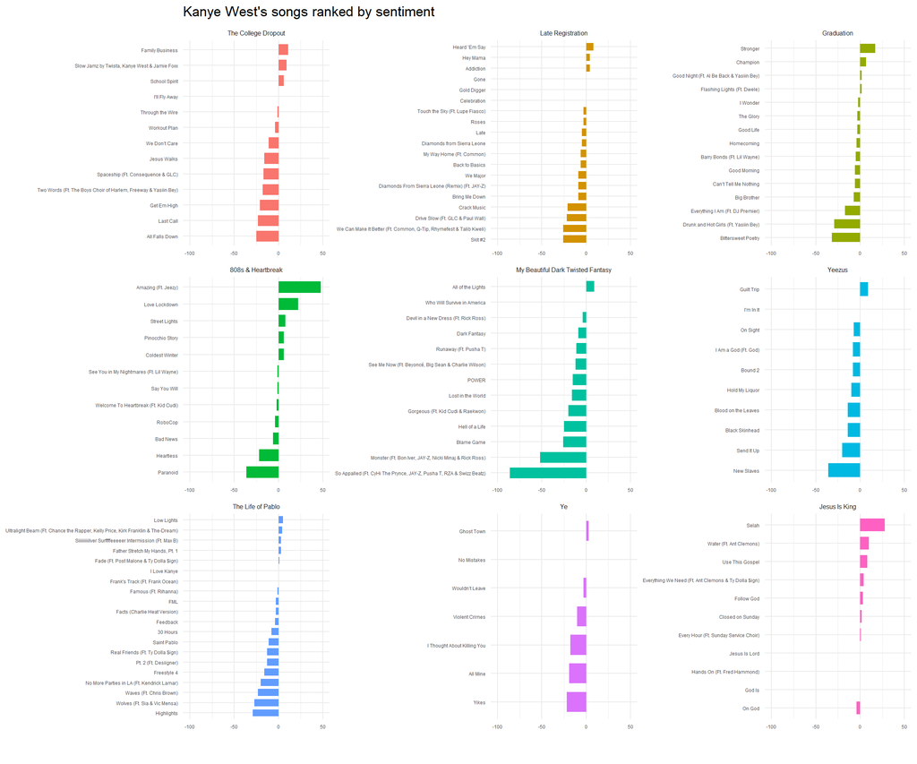

If we take a look at the songs at each extreme

**Amazing** in the album **808’s & Heartbreak**, which has the largest sentiment value in the positive direction.

**So Appalled** in **My Beautiful Dark Twisted Fantasy** which has the largest sentiment value in the negative direction.

We can see they both contain lyrics center around individual words.

**Amazing**:

```
"And no matter what, you'll never take that from me
My reign is as far as your eyes can see, it's amazing
So amazing, so amazing, so amazing, it's amazing
So amazing, so amazing, so amazing, it's amazing (Let's go)"
```

The repetition of this chorus happens multiple times in the song

**So Appalled**:

```
"I mean the shit is fuckin' ridiculous, fuckin' ridiculous
I mean the shit is fuckin' ridiculous
Five star dishes, different exotic fishes
Man this shit is fuckin' ridiculous, fuckin' ridiculous"
```

The negative sentiment here is captured around the word ridiculous which is repeated in the above chorus and also as a refrain by each rapper in the song. It is also captured by the use of profanity which is tagged as negative regardless of context.

This lead us to start to unpack another issue with sentiment analysis which takes overall sentiment as a summation of sentiment of individual words. The sentiment of So Appalled within context is a lot more nuanced than the analysis implies, *ridiculous* is essentially being used here as a way of exclaiming shock at the amount of money and fame the rappers possess.

Another useful example of this lack of context is the song **Love Lockdown**

```
## # A tibble: 101 x 6
##    track_n  line track_title   album             word   sentiment
##      <dbl> <int> <chr>         <chr>             <chr>  <chr>
##  1       5     2 Love Lockdown 808s & Heartbreak loving positive
##  2       5     3 Love Lockdown 808s & Heartbreak run    <NA>
##  3       5     4 Love Lockdown 808s & Heartbreak love   positive
##  4       5     4 Love Lockdown 808s & Heartbreak vibe   <NA>
##  5       5     4 Love Lockdown 808s & Heartbreak wrong  negative
##  6       5     5 Love Lockdown 808s & Heartbreak home   <NA>
##  7       5     7 Love Lockdown 808s & Heartbreak til    <NA>
##  8       5     7 Love Lockdown 808s & Heartbreak love   positive
##  9       5     8 Love Lockdown 808s & Heartbreak til    <NA>
## 10       5     8 Love Lockdown 808s & Heartbreak lose   negative
## # ... with 91 more rows
```

ThE words *loving* and *love* are tagged as positive but within the context of the lyrics below, you can see the problem with that interpretation:

```
I'm not loving you, the way I wanted to
What I had to do, had to run from you
I'm in love with you, but the vibe is wrong
And that haunted me, all the way home
```

In order to increase the match rate of lyrics to the sentiment vocabulary. I combined the nrc and bing sets. nrc’s 10 catergory can be eaisly binarised into positive/negative e.g trust is positive and fear is negative.

Combining both and after some deduplication we now have a vocabulary with **10252** words.

```r
head(combo)
```

```
## # A tibble: 6 x 2
##   word        sentiment
##   <chr>       <chr>
## 1 abacus      positive
## 2 abandon     negative
## 3 abandoned   negative
## 4 abandonment negative
## 5 abba        positive
## 6 abbot       positive
```

With this new vocabulary we now have a mean match rate of **32%** and a median of **30%**

Let’s see what happens if we plot this new data.

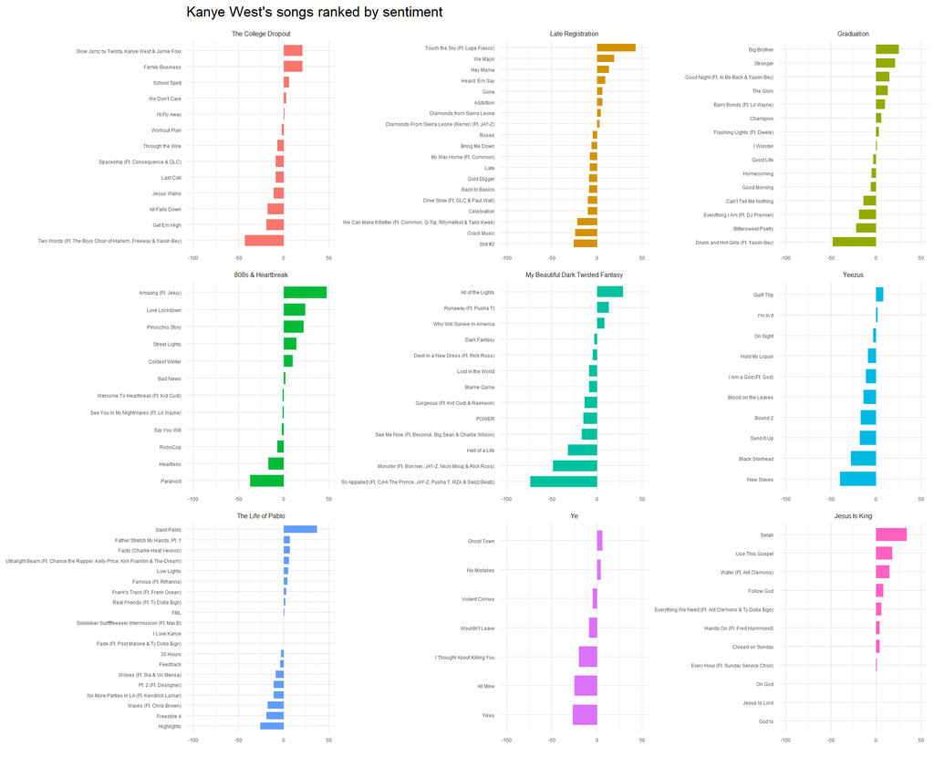

Although this is more representative than the previous chart. The issue of context is still prevalent. Profane words are still being categorised as negative and the overall sentiment of a song is not necessarily a summation of the individual sentiments of words.

The **sentimentr** package has built-in functionality for more nuanced sentiment scores that takes into account valence shifters, e.g. words that would negate something with positive or negative sentiment (‘I do **not** like it’). https://m-clark.github.io/text-analysis-with-R/sentiment-analysis.html

Sentiment analysis is an ongoing research field that deploys vastly more complex techniques than the one presented here. One could consider the use of a supervised ML algorithm trained on product review text with corresponding rating values.

Understanding how humans evaluate sentiment when reading is also useful, identifying the subject of a sentence in order to evaluate how it is being viewed would move towards a more context based analysis.